# Risk Factor Analysis

## Outcome Variable

**Outcome Variable:** pers_wast

## Predictor Variables

**Intervention Variable:** perdiar24

**Adjustment Set:**

unadjusted

## Stratifying Variables

The analysis was stratified on these variable(s):

- agecat
- studyid
- country

## Data Summary

| agecat | studyid | country | perdiar24 | pers_wast | n_cell | n |
| --- | --- | --- | --- | --- | --- | --- |
| 0-24 months | ki0047075b-MAL-ED | BANGLADESH | (0%, 5%] | 0 | 136 | 248 |
| 0-24 months | ki0047075b-MAL-ED | BANGLADESH | (0%, 5%] | 1 | 10 | 248 |
| 0-24 months | ki0047075b-MAL-ED | BANGLADESH | >5% | 0 | 91 | 248 |
| 0-24 months | ki0047075b-MAL-ED | BANGLADESH | >5% | 1 | 3 | 248 |
| 0-24 months | ki0047075b-MAL-ED | BANGLADESH | 0% | 0 | 8 | 248 |
| 0-24 months | ki0047075b-MAL-ED | BANGLADESH | 0% | 1 | 0 | 248 |
| 0-24 months | ki0047075b-MAL-ED | BRAZIL | (0%, 5%] | 0 | 100 | 217 |
| 0-24 months | ki0047075b-MAL-ED | BRAZIL | (0%, 5%] | 1 | 1 | 217 |
| 0-24 months | ki0047075b-MAL-ED | BRAZIL | >5% | 0 | 2 | 217 |
| 0-24 months | ki0047075b-MAL-ED | BRAZIL | >5% | 1 | 0 | 217 |
| 0-24 months | ki0047075b-MAL-ED | BRAZIL | 0% | 0 | 113 | 217 |
| 0-24 months | ki0047075b-MAL-ED | BRAZIL | 0% | 1 | 1 | 217 |
| 0-24 months | ki0047075b-MAL-ED | INDIA | (0%, 5%] | 0 | 178 | 241 |
| 0-24 months | ki0047075b-MAL-ED | INDIA | (0%, 5%] | 1 | 15 | 241 |
| 0-24 months | ki0047075b-MAL-ED | INDIA | >5% | 0 | 38 | 241 |
| 0-24 months | ki0047075b-MAL-ED | INDIA | >5% | 1 | 5 | 241 |
| 0-24 months | ki0047075b-MAL-ED | INDIA | 0% | 0 | 4 | 241 |
| 0-24 months | ki0047075b-MAL-ED | INDIA | 0% | 1 | 1 | 241 |
| 0-24 months | ki0047075b-MAL-ED | NEPAL | (0%, 5%] | 0 | 140 | 238 |
| 0-24 months | ki0047075b-MAL-ED | NEPAL | (0%, 5%] | 1 | 4 | 238 |
| 0-24 months | ki0047075b-MAL-ED | NEPAL | >5% | 0 | 79 | 238 |
| 0-24 months | ki0047075b-MAL-ED | NEPAL | >5% | 1 | 0 | 238 |
| 0-24 months | ki0047075b-MAL-ED | NEPAL | 0% | 0 | 15 | 238 |
| 0-24 months | ki0047075b-MAL-ED | NEPAL | 0% | 1 | 0 | 238 |
| 0-24 months | ki0047075b-MAL-ED | PERU | (0%, 5%] | 0 | 112 | 284 |
| 0-24 months | ki0047075b-MAL-ED | PERU | (0%, 5%] | 1 | 1 | 284 |
| 0-24 months | ki0047075b-MAL-ED | PERU | >5% | 0 | 160 | 284 |
| 0-24 months | ki0047075b-MAL-ED | PERU | >5% | 1 | 0 | 284 |
| 0-24 months | ki0047075b-MAL-ED | PERU | 0% | 0 | 11 | 284 |
| 0-24 months | ki0047075b-MAL-ED | PERU | 0% | 1 | 0 | 284 |

[output cut: 300 more lines]

The following strata were considered:

- agecat: 0-24 months, studyid: ki0047075b-MAL-ED, country: BANGLADESH
- agecat: 0-24 months, studyid: ki0047075b-MAL-ED, country: BRAZIL
- agecat: 0-24 months, studyid: ki0047075b-MAL-ED, country: INDIA
- agecat: 0-24 months, studyid: ki0047075b-MAL-ED, country: NEPAL
- agecat: 0-24 months, studyid: ki0047075b-MAL-ED, country: PERU
- agecat: 0-24 months, studyid: ki0047075b-MAL-ED, country: SOUTH AFRICA
- agecat: 0-24 months, studyid: ki0047075b-MAL-ED, country: TANZANIA, UNITED REPUBLIC OF
- agecat: 0-24 months, studyid: ki1000109-EE, country: PAKISTAN
- agecat: 0-24 months, studyid: ki1000109-ResPak, country: PAKISTAN
- agecat: 0-24 months, studyid: ki1000304b-SAS-FoodSuppl, country: INDIA
- agecat: 0-24 months, studyid: ki1017093-NIH-Birth, country: BANGLADESH
- agecat: 0-24 months, studyid: ki1017093b-PROVIDE, country: BANGLADESH
- agecat: 0-24 months, studyid: ki1017093c-NIH-Crypto, country: BANGLADESH
- agecat: 0-24 months, studyid: ki1112895-Guatemala BSC, country: GUATEMALA
- agecat: 0-24 months, studyid: ki1112895-iLiNS-Zinc, country: BURKINA FASO
- agecat: 0-24 months, studyid: ki1114097-CMIN, country: BANGLADESH
- agecat: 0-24 months, studyid: ki1114097-CMIN, country: BRAZIL
- agecat: 0-24 months, studyid: ki1114097-CMIN, country: GUINEA-BISSAU
- agecat: 0-24 months, studyid: ki1114097-CMIN, country: PERU
- agecat: 0-24 months, studyid: ki1114097-CONTENT, country: PERU
- agecat: 0-24 months, studyid: kiGH5241-JiVitA-4, country: BANGLADESH
- agecat: 0-6 months, studyid: ki0047075b-MAL-ED, country: BANGLADESH
- agecat: 0-6 months, studyid: ki0047075b-MAL-ED, country: BRAZIL
- agecat: 0-6 months, studyid: ki0047075b-MAL-ED, country: INDIA
- agecat: 0-6 months, studyid: ki0047075b-MAL-ED, country: NEPAL
- agecat: 0-6 months, studyid: ki0047075b-MAL-ED, country: PERU
- agecat: 0-6 months, studyid: ki0047075b-MAL-ED, country: SOUTH AFRICA
- agecat: 0-6 months, studyid: ki0047075b-MAL-ED, country: TANZANIA, UNITED REPUBLIC OF
- agecat: 0-6 months, studyid: ki1000109-EE, country: PAKISTAN
- agecat: 0-6 months, studyid: ki1000109-ResPak, country: PAKISTAN
- agecat: 0-6 months, studyid: ki1017093b-PROVIDE, country: BANGLADESH
- agecat: 0-6 months, studyid: ki1114097-CMIN, country: BANGLADESH
- agecat: 0-6 months, studyid: ki1114097-CMIN, country: PERU
- agecat: 0-6 months, studyid: ki1114097-CONTENT, country: PERU
- agecat: 6-24 months, studyid: ki0047075b-MAL-ED, country: BANGLADESH
- agecat: 6-24 months, studyid: ki0047075b-MAL-ED, country: BRAZIL
- agecat: 6-24 months, studyid: ki0047075b-MAL-ED, country: INDIA
- agecat: 6-24 months, studyid: ki0047075b-MAL-ED, country: NEPAL
- agecat: 6-24 months, studyid: ki0047075b-MAL-ED, country: PERU
- agecat: 6-24 months, studyid: ki0047075b-MAL-ED, country: SOUTH AFRICA
- agecat: 6-24 months, studyid: ki0047075b-MAL-ED, country: TANZANIA, UNITED REPUBLIC OF
- agecat: 6-24 months, studyid: ki1000109-EE, country: PAKISTAN
- agecat: 6-24 months, studyid: ki1000109-ResPak, country: PAKISTAN
- agecat: 6-24 months, studyid: ki1000304b-SAS-FoodSuppl, country: INDIA
- agecat: 6-24 months, studyid: ki1017093-NIH-Birth, country: BANGLADESH
- agecat: 6-24 months, studyid: ki1017093b-PROVIDE, country: BANGLADESH
- agecat: 6-24 months, studyid: ki1017093c-NIH-Crypto, country: BANGLADESH
- agecat: 6-24 months, studyid: ki1112895-Guatemala BSC, country: GUATEMALA
- agecat: 6-24 months, studyid: ki1112895-iLiNS-Zinc, country: BURKINA FASO
- agecat: 6-24 months, studyid: ki1114097-CMIN, country: BANGLADESH
- agecat: 6-24 months, studyid: ki1114097-CMIN, country: BRAZIL
- agecat: 6-24 months, studyid: ki1114097-CMIN, country: GUINEA-BISSAU
- agecat: 6-24 months, studyid: ki1114097-CMIN, country: PERU
- agecat: 6-24 months, studyid: ki1114097-CONTENT, country: PERU
- agecat: 6-24 months, studyid: kiGH5241-JiVitA-4, country: BANGLADESH

### Dropped Strata

Some strata were dropped due to rare outcomes:

- agecat: 0-24 months, studyid: ki0047075b-MAL-ED, country: BANGLADESH
- agecat: 0-24 months, studyid: ki0047075b-MAL-ED, country: BRAZIL
- agecat: 0-24 months, studyid: ki0047075b-MAL-ED, country: INDIA
- agecat: 0-24 months, studyid: ki0047075b-MAL-ED, country: NEPAL
- agecat: 0-24 months, studyid: ki0047075b-MAL-ED, country: PERU
- agecat: 0-24 months, studyid: ki0047075b-MAL-ED, country: SOUTH AFRICA
- agecat: 0-24 months, studyid: ki0047075b-MAL-ED, country: TANZANIA, UNITED REPUBLIC OF
- agecat: 0-24 months, studyid: ki1000109-EE, country: PAKISTAN
- agecat: 0-24 months, studyid: ki1000109-ResPak, country: PAKISTAN
- agecat: 0-24 months, studyid: ki1017093-NIH-Birth, country: BANGLADESH
- agecat: 0-24 months, studyid: ki1017093b-PROVIDE, country: BANGLADESH
- agecat: 0-24 months, studyid: ki1017093c-NIH-Crypto, country: BANGLADESH
- agecat: 0-24 months, studyid: ki1112895-Guatemala BSC, country: GUATEMALA
- agecat: 0-24 months, studyid: ki1114097-CMIN, country: BANGLADESH
- agecat: 0-24 months, studyid: ki1114097-CMIN, country: BRAZIL
- agecat: 0-24 months, studyid: ki1114097-CMIN, country: GUINEA-BISSAU
- agecat: 0-24 months, studyid: ki1114097-CMIN, country: PERU
- agecat: 0-24 months, studyid: ki1114097-CONTENT, country: PERU
- agecat: 0-6 months, studyid: ki0047075b-MAL-ED, country: BANGLADESH
- agecat: 0-6 months, studyid: ki0047075b-MAL-ED, country: BRAZIL
- agecat: 0-6 months, studyid: ki0047075b-MAL-ED, country: INDIA
- agecat: 0-6 months, studyid: ki0047075b-MAL-ED, country: NEPAL
- agecat: 0-6 months, studyid: ki0047075b-MAL-ED, country: PERU
- agecat: 0-6 months, studyid: ki0047075b-MAL-ED, country: SOUTH AFRICA
- agecat: 0-6 months, studyid: ki0047075b-MAL-ED, country: TANZANIA, UNITED REPUBLIC OF
- agecat: 0-6 months, studyid: ki1000109-EE, country: PAKISTAN
- agecat: 0-6 months, studyid: ki1000109-ResPak, country: PAKISTAN
- agecat: 0-6 months, studyid: ki1017093b-PROVIDE, country: BANGLADESH
- agecat: 0-6 months, studyid: ki1114097-CMIN, country: BANGLADESH
- agecat: 0-6 months, studyid: ki1114097-CMIN, country: PERU
- agecat: 0-6 months, studyid: ki1114097-CONTENT, country: PERU
- agecat: 6-24 months, studyid: ki0047075b-MAL-ED, country: BANGLADESH
- agecat: 6-24 months, studyid: ki0047075b-MAL-ED, country: BRAZIL
- agecat: 6-24 months, studyid: ki0047075b-MAL-ED, country: INDIA
- agecat: 6-24 months, studyid: ki0047075b-MAL-ED, country: NEPAL
- agecat: 6-24 months, studyid: ki0047075b-MAL-ED, country: PERU
- agecat: 6-24 months, studyid: ki0047075b-MAL-ED, country: SOUTH AFRICA
- agecat: 6-24 months, studyid: ki0047075b-MAL-ED, country: TANZANIA, UNITED REPUBLIC OF
- agecat: 6-24 months, studyid: ki1000109-EE, country: PAKISTAN
- agecat: 6-24 months, studyid: ki1000109-ResPak, country: PAKISTAN
- agecat: 6-24 months, studyid: ki1017093-NIH-Birth, country: BANGLADESH
- agecat: 6-24 months, studyid: ki1017093b-PROVIDE, country: BANGLADESH
- agecat: 6-24 months, studyid: ki1112895-Guatemala BSC, country: GUATEMALA
- agecat: 6-24 months, studyid: ki1114097-CMIN, country: BANGLADESH
- agecat: 6-24 months, studyid: ki1114097-CMIN, country: BRAZIL
- agecat: 6-24 months, studyid: ki1114097-CMIN, country: GUINEA-BISSAU
- agecat: 6-24 months, studyid: ki1114097-CMIN, country: PERU
- agecat: 6-24 months, studyid: ki1114097-CONTENT, country: PERU

## Methods Detail

We’re interested in the causal parameters $E[Y_a]$ for all values of $a \in \mathcal{A}$. These parameters represent the mean outcome if, possibly contrary to fact, we intervened to set all units to have $A=a$. Under the randomization and positivity assumptions, these are identified by the statistical parameters $\psi_a=E_W[E_{Y|A,W}(Y|A=a,W)]$. In addition, we’re interested in the mean of $Y$, $E[Y]$ under no intervention (the observed mean). We will estimate these parameters by using SuperLearner to fit the relevant likelihood factors – $E_{Y|A,W}(Y|A=a,W)$ and $p(A=a|W)$, and then updating our likelihood fit using a joint TMLE.

For unadjusted analyses ($W=\{\}$), initial likelihoods were estimated using Lrnr_glm to estimate the simple $E(Y|A)$ and Lrnr_mean to estimate $p(A)$. For adjusted analyses, a small library containing Lrnr_glmnet, Lrnr_xgboost, and Lrnr_mean was used.

Having estimated these parameters, we will then use the delta method to estimate relative risks and attributable risks relative to a prespecified baseline level of $A$.

# Results Detail

## Results Plots

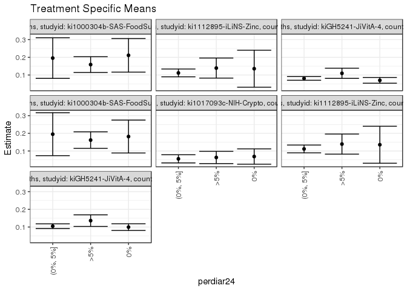

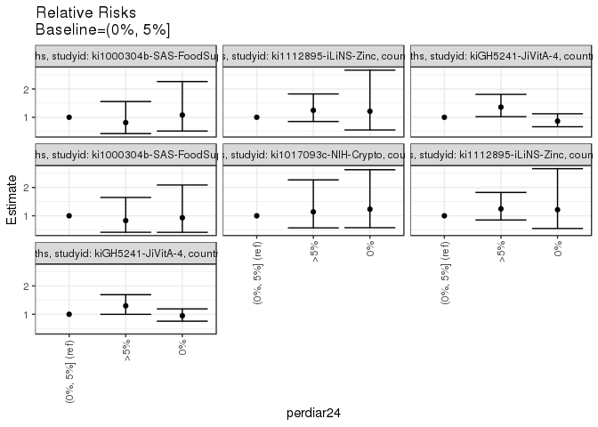

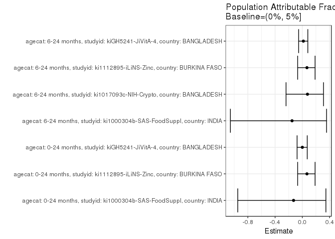

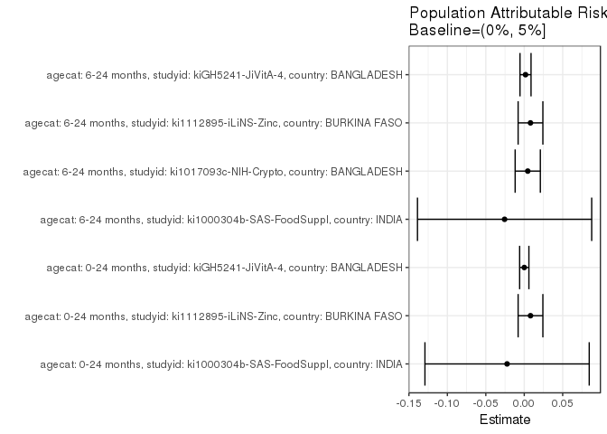

## Results Table

### Parameter: TSM

| agecat | studyid | country | intervention_level | baseline_level | estimate | ci_lower | ci_upper |
| --- | --- | --- | --- | --- | --- | --- | --- |
| 0-24 months | ki1000304b-SAS-FoodSuppl | INDIA | (0%, 5%] | NA | 0.1956522 | 0.0808597 | 0.3104446 |
| 0-24 months | ki1000304b-SAS-FoodSuppl | INDIA | >5% | NA | 0.1589147 | 0.1142443 | 0.2035852 |
| 0-24 months | ki1000304b-SAS-FoodSuppl | INDIA | 0% | NA | 0.2112676 | 0.1161896 | 0.3063456 |
| 0-24 months | ki1112895-iLiNS-Zinc | BURKINA FASO | (0%, 5%] | NA | 0.1116928 | 0.0896103 | 0.1337754 |
| 0-24 months | ki1112895-iLiNS-Zinc | BURKINA FASO | >5% | NA | 0.1391586 | 0.0823572 | 0.1959599 |
| 0-24 months | ki1112895-iLiNS-Zinc | BURKINA FASO | 0% | NA | 0.1355140 | 0.0309117 | 0.2401163 |
| 0-24 months | kiGH5241-JiVitA-4 | BANGLADESH | (0%, 5%] | NA | 0.0806310 | 0.0702342 | 0.0910279 |
| 0-24 months | kiGH5241-JiVitA-4 | BANGLADESH | >5% | NA | 0.1095890 | 0.0808274 | 0.1383506 |
| 0-24 months | kiGH5241-JiVitA-4 | BANGLADESH | 0% | NA | 0.0697847 | 0.0535981 | 0.0859713 |
| 6-24 months | ki1000304b-SAS-FoodSuppl | INDIA | (0%, 5%] | NA | 0.1951220 | 0.0736435 | 0.3166004 |
| 6-24 months | ki1000304b-SAS-FoodSuppl | INDIA | >5% | NA | 0.1618257 | 0.1152612 | 0.2083903 |
| 6-24 months | ki1000304b-SAS-FoodSuppl | INDIA | 0% | NA | 0.1818182 | 0.0886335 | 0.2750029 |
| 6-24 months | ki1017093c-NIH-Crypto | BANGLADESH | (0%, 5%] | NA | 0.0557029 | 0.0325352 | 0.0788706 |
| 6-24 months | ki1017093c-NIH-Crypto | BANGLADESH | >5% | NA | 0.0634921 | 0.0287029 | 0.0982813 |
| 6-24 months | ki1017093c-NIH-Crypto | BANGLADESH | 0% | NA | 0.0687023 | 0.0253558 | 0.1120488 |
| 6-24 months | ki1112895-iLiNS-Zinc | BURKINA FASO | (0%, 5%] | NA | 0.1116928 | 0.0896103 | 0.1337754 |
| 6-24 months | ki1112895-iLiNS-Zinc | BURKINA FASO | >5% | NA | 0.1391586 | 0.0823572 | 0.1959599 |
| 6-24 months | ki1112895-iLiNS-Zinc | BURKINA FASO | 0% | NA | 0.1355140 | 0.0309117 | 0.2401163 |
| 6-24 months | kiGH5241-JiVitA-4 | BANGLADESH | (0%, 5%] | NA | 0.1047359 | 0.0915197 | 0.1179521 |
| 6-24 months | kiGH5241-JiVitA-4 | BANGLADESH | >5% | NA | 0.1360825 | 0.1033177 | 0.1688472 |
| 6-24 months | kiGH5241-JiVitA-4 | BANGLADESH | 0% | NA | 0.0993740 | 0.0803773 | 0.1183708 |

### Parameter: E(Y)

| agecat | studyid | country | intervention_level | baseline_level | estimate | ci_lower | ci_upper |
| --- | --- | --- | --- | --- | --- | --- | --- |
| 0-24 months | ki1000304b-SAS-FoodSuppl | INDIA | NA | NA | 0.1733333 | 0.1349698 | 0.2116969 |
| 0-24 months | ki1112895-iLiNS-Zinc | BURKINA FASO | NA | NA | 0.1198322 | 0.0943748 | 0.1452897 |
| 0-24 months | kiGH5241-JiVitA-4 | BANGLADESH | NA | NA | 0.0806665 | 0.0720540 | 0.0892791 |
| 6-24 months | ki1000304b-SAS-FoodSuppl | INDIA | NA | NA | 0.1695402 | 0.1300601 | 0.2090204 |
| 6-24 months | ki1017093c-NIH-Crypto | BANGLADESH | NA | NA | 0.0602582 | 0.0425793 | 0.0779372 |
| 6-24 months | ki1112895-iLiNS-Zinc | BURKINA FASO | NA | NA | 0.1198322 | 0.0943748 | 0.1452897 |
| 6-24 months | kiGH5241-JiVitA-4 | BANGLADESH | NA | NA | 0.1063872 | 0.0957820 | 0.1169924 |

### Parameter: RR

| agecat | studyid | country | intervention_level | baseline_level | estimate | ci_lower | ci_upper |
| --- | --- | --- | --- | --- | --- | --- | --- |
| 0-24 months | ki1000304b-SAS-FoodSuppl | INDIA | (0%, 5%] | (0%, 5%] | 1.0000000 | 1.0000000 | 1.000000 |
| 0-24 months | ki1000304b-SAS-FoodSuppl | INDIA | >5% | (0%, 5%] | 0.8122308 | 0.4237765 | 1.556761 |
| 0-24 months | ki1000304b-SAS-FoodSuppl | INDIA | 0% | (0%, 5%] | 1.0798122 | 0.5154829 | 2.261946 |
| 0-24 months | ki1112895-iLiNS-Zinc | BURKINA FASO | (0%, 5%] | (0%, 5%] | 1.0000000 | 1.0000000 | 1.000000 |
| 0-24 months | ki1112895-iLiNS-Zinc | BURKINA FASO | >5% | (0%, 5%] | 1.2459041 | 0.8510261 | 1.824007 |
| 0-24 months | ki1112895-iLiNS-Zinc | BURKINA FASO | 0% | (0%, 5%] | 1.2132739 | 0.5527335 | 2.663189 |
| 0-24 months | kiGH5241-JiVitA-4 | BANGLADESH | (0%, 5%] | (0%, 5%] | 1.0000000 | 1.0000000 | 1.000000 |
| 0-24 months | kiGH5241-JiVitA-4 | BANGLADESH | >5% | (0%, 5%] | 1.3591423 | 1.0210914 | 1.809111 |
| 0-24 months | kiGH5241-JiVitA-4 | BANGLADESH | 0% | (0%, 5%] | 0.8654821 | 0.6659770 | 1.124752 |
| 6-24 months | ki1000304b-SAS-FoodSuppl | INDIA | (0%, 5%] | (0%, 5%] | 1.0000000 | 1.0000000 | 1.000000 |
| 6-24 months | ki1000304b-SAS-FoodSuppl | INDIA | >5% | (0%, 5%] | 0.8293568 | 0.4177127 | 1.646665 |
| 6-24 months | ki1000304b-SAS-FoodSuppl | INDIA | 0% | (0%, 5%] | 0.9318182 | 0.4160235 | 2.087106 |
| 6-24 months | ki1017093c-NIH-Crypto | BANGLADESH | (0%, 5%] | (0%, 5%] | 1.0000000 | 1.0000000 | 1.000000 |
| 6-24 months | ki1017093c-NIH-Crypto | BANGLADESH | >5% | (0%, 5%] | 1.1398337 | 0.5729127 | 2.267747 |
| 6-24 months | ki1017093c-NIH-Crypto | BANGLADESH | 0% | (0%, 5%] | 1.2333697 | 0.5792994 | 2.625932 |
| 6-24 months | ki1112895-iLiNS-Zinc | BURKINA FASO | (0%, 5%] | (0%, 5%] | 1.0000000 | 1.0000000 | 1.000000 |
| 6-24 months | ki1112895-iLiNS-Zinc | BURKINA FASO | >5% | (0%, 5%] | 1.2459041 | 0.8510261 | 1.824007 |
| 6-24 months | ki1112895-iLiNS-Zinc | BURKINA FASO | 0% | (0%, 5%] | 1.2132739 | 0.5527335 | 2.663189 |
| 6-24 months | kiGH5241-JiVitA-4 | BANGLADESH | (0%, 5%] | (0%, 5%] | 1.0000000 | 1.0000000 | 1.000000 |
| 6-24 months | kiGH5241-JiVitA-4 | BANGLADESH | >5% | (0%, 5%] | 1.2992918 | 0.9978450 | 1.691805 |
| 6-24 months | kiGH5241-JiVitA-4 | BANGLADESH | 0% | (0%, 5%] | 0.9488059 | 0.7559826 | 1.190811 |

### Parameter: PAR

| agecat | studyid | country | intervention_level | baseline_level | estimate | ci_lower | ci_upper |
| --- | --- | --- | --- | --- | --- | --- | --- |
| 0-24 months | ki1000304b-SAS-FoodSuppl | INDIA | (0%, 5%] | NA | -0.0223188 | -0.1291656 | 0.0845279 |
| 0-24 months | ki1112895-iLiNS-Zinc | BURKINA FASO | (0%, 5%] | NA | 0.0081394 | -0.0079574 | 0.0242362 |
| 0-24 months | kiGH5241-JiVitA-4 | BANGLADESH | (0%, 5%] | NA | 0.0000355 | -0.0059875 | 0.0060585 |
| 6-24 months | ki1000304b-SAS-FoodSuppl | INDIA | (0%, 5%] | NA | -0.0255817 | -0.1388887 | 0.0877252 |
| 6-24 months | ki1017093c-NIH-Crypto | BANGLADESH | (0%, 5%] | NA | 0.0045553 | -0.0118352 | 0.0209459 |
| 6-24 months | ki1112895-iLiNS-Zinc | BURKINA FASO | (0%, 5%] | NA | 0.0081394 | -0.0079574 | 0.0242362 |
| 6-24 months | kiGH5241-JiVitA-4 | BANGLADESH | (0%, 5%] | NA | 0.0016513 | -0.0055321 | 0.0088347 |

### Parameter: PAF

| agecat | studyid | country | intervention_level | baseline_level | estimate | ci_lower | ci_upper |
| --- | --- | --- | --- | --- | --- | --- | --- |
| 0-24 months | ki1000304b-SAS-FoodSuppl | INDIA | (0%, 5%] | NA | -0.1287625 | -0.9482279 | 0.3460186 |
| 0-24 months | ki1112895-iLiNS-Zinc | BURKINA FASO | (0%, 5%] | NA | 0.0679232 | -0.0687602 | 0.1871262 |
| 0-24 months | kiGH5241-JiVitA-4 | BANGLADESH | (0%, 5%] | NA | 0.0004403 | -0.0770832 | 0.0723840 |
| 6-24 months | ki1000304b-SAS-FoodSuppl | INDIA | (0%, 5%] | NA | -0.1508888 | -1.0560919 | 0.3557948 |
| 6-24 months | ki1017093c-NIH-Crypto | BANGLADESH | (0%, 5%] | NA | 0.0755968 | -0.2395880 | 0.3106409 |
| 6-24 months | ki1112895-iLiNS-Zinc | BURKINA FASO | (0%, 5%] | NA | 0.0679232 | -0.0687602 | 0.1871262 |
| 6-24 months | kiGH5241-JiVitA-4 | BANGLADESH | (0%, 5%] | NA | 0.0155216 | -0.0545028 | 0.0808961 |